[figure not shown]

# NumPy

- **NumPy** é a abreviatura de **Numerical Python**. Considerado um dos pacotes básicos mais importantes para processamento numérico em **Python**, proporciona um grande conjunto de funções que permitem executar cálculos numéricos facilmente;

[figure not shown]

- Para instalar basta usar: `pip3 install numpy`;
- O site oficial do pacote é https://numpy.org/ e a documentação oficial encontra-se disponível **[aqui](https://numpy.org/doc/stable/numpy-user.pdf)**;

## NumPy

- O principal objeto do **NumPy** é o arranjo (*array*) n-dimensional homogêneo. Em **NumPy** as dimensões são chamadas de *eixos*;

[figure not shown]

```python
import numpy as np
c = np.array([[[1,2],[4,3],[7,4]],[[2,2],[9,3],[7,5]],[[1,4],[3,7],[0,2]],[[9,2],[6,3],[9,8]]])
print(c.shape)
```

```
(4, 3, 2)
```

# Numpy

- Um dos motivos para **NumPy** ser tão importante para processamentos numéricos é o fato dele ter sido projetado para ser eficiente com arranjos de grandes conjuntos de dados;

```python
help("numpy")
```

[output not shown]

[output cut: 57980 more lines]

[output not shown]

# NumPy

- Os algoritmos baseados em **NumPy** geralmente são de 10 a 100 vezes mais rápidos e usam menos memória se comparamos com algoritmos baseados em **Python** normal;

```python
n = 1000000
arranjo = np.arange(n) # Arranjo com 1 milhão de inteiros
lista = list(range(n))
```

```python
%time
for _ in range(10): arranjo2 = arranjo*2 # ns: nanosegundo
```

```
CPU times: user 1e+03 ns, sys: 1e+03 ns, total: 2 µs
Wall time: 3.34 µs
```

```python
%time
for _ in range(10): lista22 = [x*2 for x in lista] # µs: microsegundo
```

```
CPU times: user 7 µs, sys: 2 µs, total: 9 µs
Wall time: 16 µs
```

# Criando arrays (arranjos)

## Criando arranjos

- A maneira mais fácil de criar um arranjo é usando a função `array(<<iterável>>)`;

```python
arranjo = np.array([1,2,3,4,5])

print(arranjo, type(arranjo))
```

```
[1 2 3 4 5] <class 'numpy.ndarray'>
```

- Um arranjo consiste em duas partes
  - Os dados;
  - Um metadado descrevendo os dados;

```python
print(arranjo, arranjo.dtype) # Mostrando os valores e o metadado do array
```

```
[1 2 3 4 5] int64
```

## Criando arranjos

- A função `arange` cria um arranjo a partir da especificação de um intervalo.

```python
a1_d = np.arange(5)

print(np.sort(a1_d)) # Ordena os elementos do array
print(np.sort(a1_d)[::-1]) # Ordem decrescente
```

```
[0 1 2 3 4]
[4 3 2 1 0]
```

- Sequências aninhadas do mesmo tamanho serão convertidas em um arranjo multidimensional;

```python
arranjo = np.array([[1,2,3,4,5], [6,7,8,9,0],np.arange(5)])

# dimensão, número de eixos, número de elementos e tipo
print(arranjo.shape, "\t", arranjo.ndim, "\t",arranjo.size ,"\t", type(arranjo))
```

```
(3, 5) 	 2 	 15 	 <class 'numpy.ndarray'>
```

## Selecionando elementos

```python
a_3d = np.array([[11,12,13],[21,22,23],[31,32,33]])

# Mostrando o arranjo, a dimensão e o número de elementos
print(a_3d,a_3d.shape,a_3d.size)
```

```
[[11 12 13]
 [21 22 23]
 [31 32 33]] (3, 3) 9
```

```python
print(a_3d[0,0])
```

```
11
```

```python
print(a_3d[0,2])
```

```
13
```

## Selecionando elementos

```python
a_3d = np.array([[11,12,13],[21,22,23],[31,32,33]])
```

```python
print(a_3d[:,2])
```

```
[13 23 33]
```

```python
print(a_3d[1:,:2])
```

```
[[21 22]
 [31 32]]
```

## Selecionando elementos

```python
b = np.arange(16).reshape(4,4)

print(b, b[::2, ::2], b.ravel()[::-1], sep="\n\n") # ravel converte em um arranjo unidimesional
```

```
[[ 0  1  2  3]
 [ 4  5  6  7]
 [ 8  9 10 11]
 [12 13 14 15]]

[[ 0  2]
 [ 8 10]]

[15 14 13 12 11 10  9  8  7  6  5  4  3  2  1  0]
```

```python
c = np.array([[ True, False, False, True ], [ False, True, True, False ],
    [ True, False, True, False ], [ False, True, False, True ]])

print(c, b[c], sep="\n\n")
```

```
[[ True False False  True]
 [False  True  True False]
 [ True False  True False]
 [False  True False  True]]

[ 0  3  5  6  8 10 13 15]
```

## Selecionando elementos

```python
print(b[-3])
```

```
[4 5 6 7]
```

```python
print(b[b%2==0])
```

[output not shown]

```python
print(b[(b > 2) & (b < 11)])
```

```
[ 3  4  5  6  7  8  9 10]
```

```python
print(b[(b > 9) | (b == 11)])
```

[output not shown]

# Algumas funções para arranjos

## Criando arranjos

```python
m = b = np.arange(24).reshape(2,3,4)
print(m,end='\n\n')
m.shape = (6,4) # Muda a dimensão do arranjo
print(m)
```

```
[[[ 0  1  2  3]
  [ 4  5  6  7]
  [ 8  9 10 11]]

 [[12 13 14 15]
  [16 17 18 19]
  [20 21 22 23]]]

[[ 0  1  2  3]
 [ 4  5  6  7]
 [ 8  9 10 11]
 [12 13 14 15]
 [16 17 18 19]
 [20 21 22 23]]
```

```python
print(m.size) # Número de elementos do arranjo
```

```
24
```

### Criando arranjos

```python
print(np.zeros((3,4))) # Cria um arranjo composto apenas de zeros.
```

```
[[0. 0. 0. 0.]
 [0. 0. 0. 0.]
 [0. 0. 0. 0.]]
```

```python
# cria um arranjo com o mesmo formato do arranjo dado, mas composto apenas de zeros.
a = np.array([[1,2],[3,4]])
print(a, np.zeros_like(a), sep="\n\n")
```

```
[[1 2]
 [3 4]]

[[0 0]
 [0 0]]
```

```python
print(1.14*np.ones(5)) # Cria um arranjo composto pelos mesmos valores
```

```
[1.14 1.14 1.14 1.14 1.14]
```

```python
print(np.full(5,1.14)) # Mais eficiente que a multiplicação acima
```

```
[1.14 1.14 1.14 1.14 1.14]
```

## Criando arranjos

```python
# Cria uma matriz identidade da ordem especificada.

print(np.identity(3, dtype=float))
```

```
[[1. 0. 0.]
 [0. 1. 0.]
 [0. 0. 1.]]
```

```python
# Cria uma matriz da ordem especificada, permitindo selecionar a diagonal que deverá conter as unidades.

print(np.eye(3, 4, -1))
```

```
[[0. 0. 0. 0.]
 [1. 0. 0. 0.]
 [0. 1. 0. 0.]]
```

```python
# Cria uma matriz diagonal

print(np.diag(np.arange(0, 20, 5)))
```

```
[[ 0  0  0  0]
 [ 0  5  0  0]
 [ 0  0 10  0]
 [ 0  0  0 15]]
```

## Criando arranjos

```python
print(np.ones((3,4))) # Cria um arranjo composto apenas de unidades.
```

```
[[1. 1. 1. 1.]
 [1. 1. 1. 1.]
 [1. 1. 1. 1.]]
```

```python
# Cria um arranjo com o mesmo formato do arranjo dado, mas composto apenas de unidades.

print(a, np.ones_like(a),sep='\n\n')
```

```
[[1 2]
 [3 4]]

[[1 1]
 [1 1]]
```

```python
# Cria um arranjo igualmente espaçado a partir da especificação de um intervalo.

print(np.linspace(0, 2, 9))
```

```
[0.   0.25 0.5  0.75 1.   1.25 1.5  1.75 2.  ]
```

## Criando arranjos

```python
# Permite a criação de um arranjo alocando nova memória, mas não preenche com nenhum valor
# Também existe a opção empty_like

print(np.empty((3,1,4), dtype=None))
```

```
[[[0. 0. 0. 0.]]

 [[0. 0. 0. 0.]]

 [[0. 0. 0. 0.]]]
```

```python
# No entanto, é necessário tomar cuidado, porque os elementos do arranjo
# conterão o número representado pelo lixo da memória onde o arranjo foi criado,
# e isso pode gerar problemas.

print(np.empty((2,3,4), dtype=None))
```

```
[[[ 2.29371359e-316  0.00000000e+000  6.91129130e-310  6.91129132e-310]
  [ 6.91129130e-310  6.91128860e-310  6.91129120e-310  6.91128857e-310]
  [ 6.91128896e-310  6.91129132e-310  6.91128948e-310  6.91129127e-310]]

 [[ 6.91129124e-310  6.91129133e-310  6.91129131e-310  6.91128860e-310]
  [-2.11690731e-011  6.91128859e-310  6.91128860e-310  5.84209835e+237]
  [ 6.91128859e-310  6.91128860e-310  4.22391340e+082  6.91128859e-310]]]
```

### Concatenando arranjos

```python
arr1, arr2 = np.array([1,2,3,4]), np.arange(5,9)
print(np.concatenate((arr1,arr2))) # Não esqueça de usar parênteses
```

```
[1 2 3 4 5 6 7 8]
```

```python
# Concatenando arranjos
arr1, arr2 = np.array([[1,2],[3,4]]), np.arange(5,9).reshape(2,2)

print(np.concatenate((arr1,arr2),axis=0),np.concatenate((arr1,arr2),axis=0).shape, end='\n\n')
print(np.concatenate((arr1,arr2),axis=1),np.concatenate((arr1,arr2),axis=1).shape)
```

```
[[1 2]
 [3 4]
 [5 6]
 [7 8]] (4, 2)

[[1 2 5 6]
 [3 4 7 8]] (2, 4)
```

```python
print(np.vstack((arr1,arr2)), np.hstack((arr1,arr2)),sep='\n\n')
```

[output not shown]

## Dividindo arranjos

```python
c = np.arange(24).reshape(2,3,4)
print(np.split(c,2))
```

```
[array([[[ 0,  1,  2,  3],
        [ 4,  5,  6,  7],
        [ 8,  9, 10, 11]]]), array([[[12, 13, 14, 15],
        [16, 17, 18, 19],
        [20, 21, 22, 23]]])]
```

```python
print(np.hsplit(c,3))
```

```
[array([[[ 0,  1,  2,  3]],

       [[12, 13, 14, 15]]]), array([[[ 4,  5,  6,  7]],

       [[16, 17, 18, 19]]]), array([[[ 8,  9, 10, 11]],

       [[20, 21, 22, 23]]])]
```

```python
print(np.vsplit(c,2))
```

```
[array([[[ 0,  1,  2,  3],
        [ 4,  5,  6,  7],
        [ 8,  9, 10, 11]]]), array([[[12, 13, 14, 15],
        [16, 17, 18, 19],
        [20, 21, 22, 23]]])]
```

# Copiando arranjos

```python
c_copia = c

print(hex(id(c)), hex(id(c_copia)))
```

```
0x7ff5c2c18450 0x7ff5c2c18450
```

```python
c_copia = c.copy() # Melhor forma de clonar um arranjo

print(hex(id(c)), hex(id(c_copia)))
```

```
0x7ff5c2c18450 0x7ff5c2c18d50
```

# Tipos de dados

## Tipos de dados

- **NumPy** suporta grande variedade de tips de dados. A listagem completa encontra-se disponível na documentação oficial https://numpy.org/doc/stable/user/basics.types.html;

```python
# Para converter o tipo de dado use o método astype

novo_arranjo = np.array([1,2,3,4,5])

print(novo_arranjo.dtype, novo_arranjo.astype(np.float64), novo_arranjo.astype(np.float64).dtype)
```

```
int64 [1. 2. 3. 4. 5.] float64
```

```python
arranjo_str = np.array(['1.2', '2.5', '-3.14', '9.25'])

# Atenção: astype sempre cria um novo array, uma cópia dos dados!
print(arranjo_str, arranjo_str.astype(np.float64))
```

```
['1.2' '2.5' '-3.14' '9.25'] [ 1.2   2.5  -3.14  9.25]
```

# Aritmética de arranjos

# Aritmética de arranjos

```python
# Usar laço for em NumPy torna o código ineficiente!

def soma(n):
    a, b, c = list(range(n)), list(range(n)), []
    for i in range(len(a)):
        a[i] = i ** 2
        b[i] = i ** 3
        c.append(a[i] + b[i])
    return c

print(soma(4), type(soma(4)), sep="\n")
```

```
[0, 2, 12, 36]
<class 'list'>
```

### Aritmética de arranjos

- Os arranjos permitem realizar operações aritméticas sem necessidade de usar o laço `for`;

```python
# Usando NumPy - Não há necessidade de laços for para realizar processamentos complexos
import numpy as np

def np_soma(n):
    a, b = np.arange(n) ** 2, np.arange(n) ** 3
    return a + b

print(np_soma(4), type(np_soma(4)),sep="\n")
```

```
[ 0  2 12 36]
<class 'numpy.ndarray'>
```

### Aritmética de arranjos

- Qualquer operação aritmética entre arranjos da mesma dimensão faz a operação ser aplicada em todos os elementos;

```python
import numpy as np

x, y = np.arange(4).reshape(2,2), np.arange(5,9).reshape(2,2)
print(x, y, x+y, sep="\n\n")
```

```
[[0 1]
 [2 3]]

[[5 6]
 [7 8]]

[[ 5  7]
 [ 9 11]]
```

```python
print(x, y, x*y, sep="\n\n")
```

```
[[0 1]
 [2 3]]

[[5 6]
 [7 8]]

[[ 0  6]
 [14 24]]
```

### Aritmética de arranjos

```python
print(x, 3*x, sep="\n\n")
```

```
[[0 1]
 [2 3]]

[[0 3]
 [6 9]]
```

```python
print(y, 1/y, sep="\n\n")
```

```
[[5 6]
 [7 8]]

[[0.2        0.16666667]
 [0.14285714 0.125     ]]
```

```python
print(x, x**0.5, sep="\n\n")
```

```
[[0 1]
 [2 3]]

[[0.         1.        ]
 [1.41421356 1.73205081]]
```

### Aritmética de arranjos

- Funções para análise exploratória:
  - Média: `np.mean`, método equivalente `x.mean()`, sendo **x** um arranjo;
  - Desvio padrão: `np.std`, método equivalente `x.std()`
  - Variância: `np.var`;
  - Soma: `np.sum`, método equivalente `x.sum()`;
  - Produto: `np.prod`;
  - Soma e produto acumulado: `np.cumsum`, `np.cumprod`;
  - Mínimo e Máximo: `np.min`, `np.max`, métodos equivalentes `x.min()` e `x.max`;
  - Índice do mímino e o máximo: `np.argmin`, `np.argmax`;
  - Avaliação de elementos nulos: `np.all`, `np.any`.

### Aritmética de arranjos

```python
print(np.min(x), x.max(), np.mean(x), np.cumsum(x), np.round(x.std(),3), sep='\n')
```

```
0
3
1.5
[0 1 3 6]
1.118
```

```python
np.info(np.mean) # Para revisar a documentação de uma função específica do NumPy
```

[output not shown]

[output cut: 47 more lines]

[output not shown]

## Aritmética de arranjos

- Outras funções encontradas no **NumPy**:
  - Funções trigonométricas: `np.cos`, `np.sin`, `np.tan`;
  - Funções trigonométricas inversas: `np.arccos`, `np.arcsin`, `np.arctan`;
  - Funções trigonométricas hiperbólicas: `np.cosh`, `np.sinh`, `np.tanh`, `np.arccosh`, `np.arcsinh`, `np.arctanh`;
  - Raíz quadrada: `np.sqrt`;
  - Exponencial: `np.exp`;
  - Logaritmos: `np.log` (natural), `np.log2` (base 2), `np.log10` (base 10);
  - Constantes: `np.e`, `np.pi`

## Aritmética de arranjos

- Mais funções:
  - Soma, subtração, multiplicação e divisão: `np.add`, `np.subtract,`, `np.multiply`, `np.divide`;
  - Potenciação: `np.power`;
  - Resto da divisão: `np.remainder`;
  - Raíz quadrada: `np.sqrt`;
  - Recíproco (Inverso): `np.reciprocal`;
  - Parte real, imaginária e conjugado: `np.real`, `np.imag`, `np.conj`;
  - Módulo e sinal: `np.abs`, `np.sign`;
  - Arredondamento: `np.floor`, `np.ceil`, `np.rint`, `np.round`;

## Funções para condicionais

```python
x = np.linspace(-4, 4, 9)
print("x = {0}\n".format(x))

# Retorna os elementos escolhidos de um array dependendo da condição
print(np.where(x < 0, x**2, x**3))
```

```
x = [-4. -3. -2. -1.  0.  1.  2.  3.  4.]

[16.  9.  4.  1.  0.  1.  8. 27. 64.]
```

```python
# Escolhe valores de uma lista de arrays dependendo do valores de
# um determinado array de índices

print(np.choose([0, 0, 0, 1, 1, 1, 2, 2, 2], [x**2, x**3, x**4]))
```

```
[ 16.   9.   4.  -1.   0.   1.  16.  81. 256.]
```

```python
# Escolhe valores de uma lista de arrays dependendo de uma lista de condições

print(np.select([x < -1, x < 2, x >= 2], [x**2, x**3, x**4]))
```

```
[ 16.   9.   4.  -1.   0.   1.  16.  81. 256.]
```

## Funções para condicionais

```python
x = np.linspace(-4, 4, 9)
print("x = {0}\n".format(x))

# Retorna um array com índices de elementos diferentes de zero

print(np.nonzero(abs(x) > 2))
```

```
x = [-4. -3. -2. -1.  0.  1.  2.  3.  4.]

(array([0, 1, 7, 8]),)
```

```python
# Executa uma operação AND elementar

print(np.logical_and(x>1, x<4))
```

```
[False False False False False False  True  True False]
```

```python
# Executa uma operação NOT elementar

print(np.logical_not(x<3))
```

```
[False False False False False False False  True  True]
```

## Funções para condicionais

```python
x = np.linspace(-4, 4, 9)
print("x = {0}\n".format(x))

# np.logical_or e np.logical_xor: Operações OR/XOR (exclusivo) elementares

print(np.logical_or(x < 1, x > 3))
```

```
x = [-4. -3. -2. -1.  0.  1.  2.  3.  4.]

[ True  True  True  True  True False False False  True]
```

```python
print(np.logical_xor(x < 1, x > 3)) # OU exclusivo (um ou outro)
```

```
[ True  True  True  True  True False False False  True]
```

```python
print(np.logical_or(True, True), np.logical_xor(True, True))
```

```
True False
```

## Funções para operações entre conjuntos

```python
a = np.arange(10)
b = np.array([1,1,2,3,3,4,5,6,7,8])

print(np.unique(b)) # Cria um novo array com elementos únicos, onde cada valor aparece apenas uma vez
```

```
[1 2 3 4 5 6 7 8]
```

```python
print(np.in1d(a,b)) # Testa a existência dos elementos de um array em outro
```

```
[False  True  True  True  True  True  True  True  True False]
```

```python
print(np.intersect1d(a,b)) # Interseção entre arrays
```

```
[1 2 3 4 5 6 7 8]
```

```python
print(np.setdiff1d(a,b)) # Operação diferença, a mesma operação entre conjuntos
```

```
[0 9]
```

```python
print(np.union1d(a,b)) # União entre arrays
```

```
[0 1 2 3 4 5 6 7 8 9]
```

## Funções para operações entre conjuntos

```python
matriz = np.arange(1, 7).reshape(2, 3)

print(matriz, "\n\n", np.transpose(matriz)) # Trasposta de uma matriz
```

```
[[1 2 3]
 [4 5 6]]

 [[1 4]
 [2 5]
 [3 6]]
```

```python
print(np.flip(matriz)) # Inverte os elementos em cada linha/coluna.
```

```
[[6 5 4]
 [3 2 1]]
```

```python
print(np.fliplr(matriz), "\n\n", np.flipud(matriz)) # Inverte os elementos em cada linha/coluna.
```

```
[[3 2 1]
 [6 5 4]]

 [[4 5 6]
 [1 2 3]]
```

## Funções para operações entre conjuntos

```python
print(np.rot90(matriz)) # Gira os elementos ao longo dos dois primeiros eixos em 90 graus
```

```
[[3 6]
 [2 5]
 [1 4]]
```

```python
print(np.sort(matriz)) # Ordena os elementos de um array ao longo de um eixo especificado
```

```
[[1 2 3]
 [4 5 6]]
```

```python
m1 = np.arange(1, 7).reshape(2, 3)
m2 = np.arange(1, 7).reshape(3, 2)

print(np.dot(m1,m2)) # Multiplicação de matrizes (produto escalar)
```

```
[[22 28]
 [49 64]]
```

### Funções para operações entre conjuntos

```python
print(a,b,np.inner(a,b)) # Produto interno
```

```
[0 1 2 3 4 5 6 7 8 9] [1 1 2 3 3 4 5 6 7 8] 246
```

```python
print(np.outer(a,b)) # Produto externo
```

```
[[ 0  0  0  0  0  0  0  0  0  0]
 [ 1  1  2  3  3  4  5  6  7  8]
 [ 2  2  4  6  6  8 10 12 14 16]
 [ 3  3  6  9  9 12 15 18 21 24]
 [ 4  4  8 12 12 16 20 24 28 32]
 [ 5  5 10 15 15 20 25 30 35 40]
 [ 6  6 12 18 18 24 30 36 42 48]
 [ 7  7 14 21 21 28 35 42 49 56]
 [ 8  8 16 24 24 32 40 48 56 64]
 [ 9  9 18 27 27 36 45 54 63 72]]
```

```python
print(np.kron(m1,m2)) # Produto Kronecker
```

```
[[ 1  2  2  4  3  6]
 [ 3  4  6  8  9 12]
 [ 5  6 10 12 15 18]
 [ 4  8  5 10  6 12]
 [12 16 15 20 18 24]
 [20 24 25 30 30 36]]
```

# Manipulação de arquivos com numpy

## Salvando e carregando arquivos

```python
m3 = np.arange(1,9)
print(m3)

# 1. Salvando arquivos com np.save

np.save('filename', m3)  # Salva o arquivo com extensão npy
```

```
[1 2 3 4 5 6 7 8]
```

```python
np.load("filename.npy") # Carrega o arquivo
```

```
array([1, 2, 3, 4, 5, 6, 7, 8])
```

```python
np.savez("filename", x = m3) # Salva o arquivo com extensão npz
```

```python
arquivo = np.load("filename.npz") # Carrega o arquivo
print(arquivo["x"])
```

```
[1 2 3 4 5 6 7 8]
```

## Salvando e carregando arquivos

```python
# 2. Salvando arquivos com np.savetxt

np.savetxt("filename.csv",m3, header='dados', comments='') # Salva em arquivos de texto
```

```python
np.loadtxt('filename.csv') # Carrega o arquivo
```

```
array([1., 2., 3., 4., 5., 6., 7., 8.])
```

## Salvando e carregando arquivos

```python
np.info(np.savetxt)
```

[output not shown]

[output cut: 64 more lines]

[output not shown]

## Outras formas de manipular arquivos

```python
# Para abrir um arquivo use a função open
arquivo = open("arquivo.txt")

print(arquivo)
```

```
<_io.TextIOWrapper name='arquivo.txt' mode='r' encoding='UTF-8'>
```

```python
# Para ler o conteúdo do arquivo linha por linha
linha = arquivo.readline() # a variável linha é uma string

print(linha, type(linha))
```

[output not shown]

```python
# Para ler todas as linhas podemos usar um loop
linhas = arquivo.readlines()
print(linhas)
```

```
['Primeira linha do arquivo\n', 'Segunda linha do arquivo\n', 'Terceira linha do arquivo\n', 'Quarta linha do arquivo\n', 'Quinta linha do arquivo\n']
```

## Outras formas de manipular arquivos

- Tome cuidado quando usa `readlines()`, já que, quando você utiliza essa função, o carregamento do arquivo é completo. Dessa forma, se o arquivo é muito grande, você pode comprometer o uso da memória do computador. Recomenda-se só para arquivos pequenos.

```python
# Para fechar o arquivo use close

arquivo = open("arquivo.txt")

for i, linha in enumerate(arquivo):
    linha = linha.rstrip("\n") # Remove a quebra de linha
    print("%4d: %s" %(i, linha))

arquivo.close()
```

```
   0: Primeira linha do arquivo
   1: Segunda linha do arquivo
   2: Terceira linha do arquivo
   3: Quarta linha do arquivo
   4: Quinta linha do arquivo
```

## Outras formas de manipular arquivos

- A função `open` recebe um parâmetro opcional para indicar o mode de carregamento do arquivo: **r** (leitura), **w** (escrita) e **a** (modo escrita, posicionando no final do arquivo). O padrão de carregamento é **r**.

```python
ola = open("ola_mundo.py", "w")
ola.write("print('olá mundo!')")
ola.close()
```

## Estatística com Numpy

## Geração de números pseudo-aleatórios

```python
rng = np.random.default_rng(12345) # fixando a semente

print(rng.random(10))  # Números uniformes no intervalo (0,1)
```

```
[0.22733602 0.31675834 0.79736546 0.67625467 0.39110955 0.33281393
 0.59830875 0.18673419 0.67275604 0.94180287]
```

```python
print(rng.random((3,2))) # Matriz com números uniformes no intervalo (0,1)
```

[output not shown]

```python
print(rng.integers(low = 0, high = 5, size = 10)) # Números inteiros
```

```
[4 1 3 4 2 1 1 1 3 1]
```

## Geração de números pseudo-aleatórios

[figure not shown]

```python
import matplotlib.pyplot as plt
plt.style.use('seaborn') # Use print(plt.style.available) para mais opções

rng = np.random.default_rng(12345) # fixando a semente
n = 1000 # Tamanho de amostra

fig, axes = plt.subplots(1, 3, figsize=(12, 3))
axes[0].hist(rng.random(n))
axes[0].set_title("Uniforme(0,1)")
axes[1].hist(rng.standard_normal(n))
axes[1].set_title("Normal padrão")
axes[2].hist(rng.integers(low = 0, high = 5, size = n), bins=9, align='left')
axes[2].set_title("Uniforme discreta(1, 10)")

plt.show()
```

## Geração de números pseudo-aleatórios

```python
# Informação sobre os geradores implementados, vide a documentação:
# https://numpy.org/doc/stable/reference/random/bit_generators/
np.info(np.random)
```

[output not shown]

[output cut: 65 more lines]

[output not shown]

## Geração de números pseudo-aleatórios

```python
poisson = rng.poisson(10,5)
print(poisson)

# Seleciona aleatoriamente um número determinado de elementos do arranjo
print(rng.choice(poisson,2))

# Embaralha os elementos do arranjo
rng.shuffle(poisson)
print(poisson)
```

```
[ 8 14  8 11  7]
[14  8]
[ 8  7 14 11  8]
```

## Geração de números pseudo-aleatórios

```python
# Histograma com a densidade normal
from scipy.stats import norm
import matplotlib.pyplot as plt

plt.style.use('seaborn') # Use print(plt.style.available) para mais opções

rng = np.random.default_rng(12345) # fixando a semente
n = 1000                           # Tamanho de amostra

dados = rng.standard_normal(n)
mu, std = norm.fit(dados)
```

## Geração de números pseudo-aleatórios

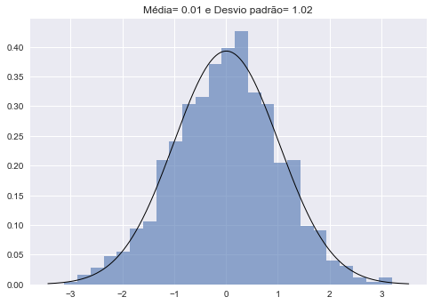

```python
# Histograma com a densidade normal
plt.hist(dados, bins=25, density=True, alpha=0.6) # Histograma

xmin, xmax = plt.xlim()
x = np.linspace(xmin, xmax, n)
p = norm.pdf(x, mu, std)

plt.plot(x, p, 'k', linewidth=1) # Curva da densidade
title = "Média= {:.2f} e Desvio padrão= {:.2f}".format(mu, std)
plt.title(title)
plt.show()
```

## Geração de números pseudo-aleatórios

```python
import numpy as np
from matplotlib import pyplot as plt

rng = np.random.default_rng(54321); n=4**2
X = rng.integers(low = 0, high = 9, size = n).reshape(int(np.sqrt(n)),int(np.sqrt(n)))
```

## Geração de números pseudo-aleatórios

```
[[0 6 8 7]
 [5 4 6 0]
 [3 4 7 1]
 [8 6 6 3]]
```

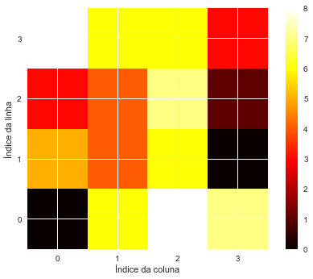

```python
print(X)
plt.imshow(X, cmap = 'hot', origin = 'lower')
plt.xticks([0, 1, 2, 3], ['0', '1', '2', '3']); plt.yticks([0, 1, 2, 3], ['0', '1', '2', '3'])
plt.xlabel('Índice da coluna'); plt.ylabel('Índice da linha')
_ = plt.colorbar()
```

## Geração de números pseudo-aleatórios

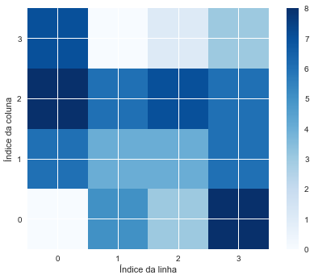

```python
# Para verificar outras opções de cores:
# https://matplotlib.org/2.0.2/examples/color/colormaps_reference.html ou
# https://matplotlib.org/2.0.2/users/colormaps.html
plt.imshow(np.transpose(X), cmap = 'Blues', origin="lower")
plt.xticks([0, 1, 2, 3], ['0', '1', '2', '3'])
plt.yticks([0, 1, 2, 3], ['0', '1', '2', '3'])
plt.xlabel('Índice da linha'); plt.ylabel('Índice da coluna')
_ = plt.colorbar()
```

# Desafio

### Comparação de genomas

Pretende-se comparar duas sequências de DNA: **SARS-CoV-2** identificado na cidade de Wuhan (China) e o Virus da **Influenza A** identificado na California (US).

O DNA é uma molécula presente em todos os seres vivos, que é responsável por armazenar as caracterı́sticas hereditárias. Ela é composta por sequências de nucleotı́deos, que podem ser de quatro tipos: Adenina (**A**), Timina (**T**), Citosina (**C**) ou Guanina (**G**).

Neste estudo de caso, queremos avaliar se estruturas com funções parecidas de organismos diferentes têm diferenças. Para isso vamos avaliar a quantidade de pares de nucleotı́deos.

### Comparação de genomas

Os dados utilizados para este estudo referem-se a sequências de DNA disponı́veis nos seguintes links: **[SARS-CoV-2 Wuhan-Hu-1](https://www.ncbi.nlm.nih.gov/nuccore/NC_045512.2?report=fasta)** e **[Virus da Influenza A (California/07/2009(H1N1))](https://www.ncbi.nlm.nih.gov/nuccore/CY266194.1?report=fasta)**.

Para comparar as duas estruturas requere-se um mapa de calor (Heatmap) que permita realizar a comparação dos pares de nucleotı́deos. Comente sobre os resultados encontrados.

[figure not shown]

# Resultado final

[figure not shown]

```python
# Solução do desafio
covid19 = open("./dataset/covid19.fasta").read()
covid19 = covid19[97:]

covid19 = covid19.replace('\n','')

cont = {key: [covid19[k] + covid19[k+1] for k in range(len(covid19)-1)].count(key)
        for key, value in cont.items()}
valores = np.array([value for value in cont.values()]).reshape(4,4)
```

```python
influenza = open("./dataset/influenza.fasta").read()
influenza = influenza[104:]

influenza = influenza.replace('\n','')

cont_inf = {key: [influenza[k] + influenza[k+1] for k in range(len(influenza)-1)].count(key)
        for key, value in cont_inf.items()}
valores_inf = np.array([value for value in cont_inf.values()]).reshape(4,4)
```

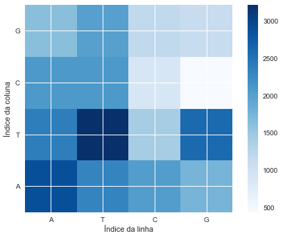

```python
# Mapa de calor sequência Covid-19

_ = plt.imshow(valores, cmap = 'Blues', origin="lower")
plt.xticks([0, 1, 2, 3], ['A', 'T', 'C', 'G'])
plt.yticks([0, 1, 2, 3], ['A', 'T', 'C', 'G'])
plt.xlabel('Índice da linha'); plt.ylabel('Índice da coluna')
_ = plt.colorbar()
```

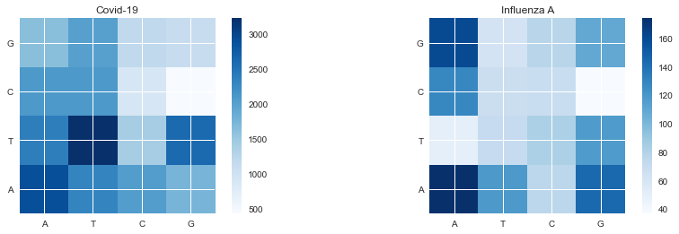

```python
# Comparação mapas de calor Covid-19 e Influenza A

fig, axes = plt.subplots(1, 2, figsize=(15, 4))
plt.setp(axes, xticks=[0, 1, 2, 3], xticklabels=['A', 'T', 'C', 'G'],
        yticks=[0, 1, 2, 3], yticklabels=['A', 'T', 'C', 'G'])

# Mapa de calor sequência do Covid-19
z1_plot = axes[0].imshow(valores, cmap = 'Blues', origin="lower")
axes[0].set_title("Covid-19")
plt.colorbar(z1_plot,ax=axes[0])

# Mapa de calor sequência da Influenza A
z2_plot = axes[1].imshow(valores_inf, cmap = 'Blues', origin="lower")
axes[1].set_title("Influenza A")
_ = plt.colorbar(z2_plot,ax=axes[1])
```